# Mini-Project 04

Just the Fact(-Check)s, Ma’am!

Author

Caitlin Uang

Published

December 7, 2025

## Summary

The U.S. Bureau of Labor Statistics (BLS) releases many of the nation’s most important economic indicators, including monthly employment figures from the Current Employment Statistics (CES) program. The CES “jobs number” is widely followed by policymakers, investors, and journalists and is routinely revised as more complete data become available.

The dismissal of Commissioner Erika McEntarfer in August 2025 sparked immediate concern among economists across the political spectrum, who warned that even the appearance of political influence could undermine trust in BLS data. Supporters of the President justified the action by pointing to the size and direction of recent CES revisions, arguing that the initial estimates had become unreliable. Defenders of BLS countered that revisions are a normal feature of high-frequency statistical reporting and that Commissioners have almost no ability to preview or alter CES estimates before release. This project analyzes CES employment estimates and their revisions over time to evaluate how large revisions typically are, whether they display consistent patterns, and how revision behavior has evolved across decades.

## Data Aqcuisition

### Final CES Estimates

```r
library(tidyverse)
library(httr2)
library(rvest)
library(lubridate)
library(htmltools)
library(purrr)
library(DT)
library(scales)


# Create HTTP POST request to BLS
ces_req <- request("https://data.bls.gov/pdq/SurveyOutputServlet") |>
  req_method("POST") |>
  req_body_form(
    request_action = "get_data",
    reformat = "true",
    from_results_page = "true",
    from_year = "1979",
    to_year = "2025",
    initial_request = "false",
    data_tool = "surveymost",
    series_id = "CES0000000001",
    original_annualAveragesRequested = "false"
  )

# Perform request & parse HTML
ces_html <- ces_req |>
  req_perform() |>
  resp_body_html() |>
  html_elements("table")

ces_table <- ces_html |>
  map(~ html_table(.x, fill = TRUE)) |>
  keep(~ ncol(.x) > 5) |>
  first()

# Clean and pivot data to long format
ces_levels <- ces_table |>
  mutate(Year = as.integer(Year)) |>
  pivot_longer(
    cols = -Year,
    names_to = "month",
    values_to = "level"
  ) |>
  mutate(
    month = str_sub(month, 1, 3),
    date = ym(paste(Year, month)),
    level = as.numeric(str_replace_all(level, ",", ""))
  ) |>
  drop_na(level, date) |>
  arrange(date) |>
  select(date,level)

# Display datatable
ces_levels |>
  datatable(
    rownames = FALSE,
    caption = tags$caption(
    style = 'caption-side: top; text-align: center; font-size: 20px; font-weight: bold;',"CES Total Nonfarm Payroll (Seasonally Adjusted) from January 1979 - July 2025"),
    options =
      list(
        searching=FALSE,
        info=FALSE,
        lengthChange = FALSE
        )
    )
```

| date | level |
| --- | --- |
| 1979-01-01 | 88808 |
| 1979-02-01 | 89055 |
| 1979-03-01 | 89479 |
| 1979-04-01 | 89417 |
| 1979-05-01 | 89789 |
| 1979-06-01 | 90108 |
| 1979-07-01 | 90217 |
| 1979-08-01 | 90300 |
| 1979-09-01 | 90327 |
| 1979-10-01 | 90481 |

[output cut: 549 more lines]

### CES Revisions

```r
# Scrape the CES revisions page
rev_html <- request("https://www.bls.gov/web/empsit/cesnaicsrev.htm") |>
  req_headers(
    "User-Agent" = "Mozilla/5.0 (Windows NT 10.0; Win64; x64) AppleWebKit/537.36",
    "Accept" = "text/html,application/xhtml+xml,application/xml;q=0.9,*/*;q=0.8",
    "Accept-Language" = "en-US,en;q=0.5",
    "Referer" = "https://www.bls.gov/"
  ) |>
  req_perform() |>
  resp_body_html()

# Function to extract revision data for a single year
extract_year <- function(year, html) {

  # Try to find table by year ID
  tbl_node <- html |> html_element(paste0("#", year))

  # Return empty if table doesn't exist
  if (inherits(tbl_node, "xml_missing")) {
    return(tibble(
      date = as.Date(character()),
      original = numeric(),
      final = numeric(),
      revision = numeric()
    ))
  }

  # Extract and process the table
  tbl <- tbl_node |>
    html_element("tbody") |>
    html_table(fill = TRUE, header = FALSE) |>
    slice(1:12) |>
    select(month = 1, original = 3, final = 5) |>
    mutate(
      original = as.numeric(str_remove_all(original, "[^0-9-]")),
      final = as.numeric(str_remove_all(final, "[^0-9-]")),
      date = ym(paste(year, month)),
      revision = final - original
    ) |>
    select(date, original, final, revision) |>
    filter(!is.na(final))

  return(tbl)
}

# Find years with tables available
available_years <- rev_html |>
  html_elements("table") |>
  html_attr("id") |>
  as.numeric() |>
  na.omit() |>
  sort()

# Extract data for all available years
ces_revisions <- map_dfr(available_years, extract_year, html = rev_html)

# Display datatable
ces_revisions |>
  datatable(
    rownames = FALSE,
    caption = tags$caption(
    style = 'caption-side: top; text-align: center; font-size: 20px; font-weight: bold;',"Revisions to the CES Non-Farm Payroll Employment number \n(January 1979 - July 2025)"),
    options = list(
      searching = FALSE,
      info = FALSE,
      lengthChange = FALSE
    )
  )
```

| date | original | final | revision |
| --- | --- | --- | --- |
| 1979-01-01 | 325 | 243 | -82 |
| 1979-02-01 | 301 | 294 | -7 |
| 1979-03-01 | 324 | 445 | 121 |
| 1979-04-01 | 72 | -15 | -87 |
| 1979-05-01 | 171 | 291 | 120 |
| 1979-06-01 | 97 | 225 | 128 |
| 1979-07-01 | 44 | 87 | 43 |
| 1979-08-01 | 2 | 49 | 47 |
| 1979-09-01 | 135 | 41 | -94 |
| 1979-10-01 | 306 | 179 | -127 |

[output cut: 549 more lines]

## Data Integration and Exploration

To investigate trends in CES levels and revisions, both tables were joined together to perform exploratory data analysis.

```r
# Join both tables using left join
ces_joined <- ces_levels |>
  left_join(ces_revisions, by = "date") |>
  arrange(date) |>
  mutate(
    abs_revision = abs(revision),
    pct_revision = percent(revision / final, accuracy = 1),
    year = year(date)
  ) |>
  select(date, level, original, final, revision, abs_revision, pct_revision)

# Display datatable
ces_joined |>
  datatable(
    rownames = FALSE,
    caption = tags$caption(
    style = 'caption-side: top; text-align: center; font-size: 20px; font-weight: bold;',"CES Non-Farm Payroll Employment Combined Levels and Revisions  \n(January 1979 - July 2025)"),
    options = list(
      searching = FALSE,
      info = FALSE,
      lengthChange = FALSE
    )
  )
```

| date | level | original | final | revision | abs_revision | pct_revision |
| --- | --- | --- | --- | --- | --- | --- |
| 1979-01-01 | 88808 | 325 | 243 | -82 | 82 | -34% |
| 1979-02-01 | 89055 | 301 | 294 | -7 | 7 | -2% |
| 1979-03-01 | 89479 | 324 | 445 | 121 | 121 | 27% |
| 1979-04-01 | 89417 | 72 | -15 | -87 | 87 | 580% |
| 1979-05-01 | 89789 | 171 | 291 | 120 | 120 | 41% |
| 1979-06-01 | 90108 | 97 | 225 | 128 | 128 | 57% |
| 1979-07-01 | 90217 | 44 | 87 | 43 | 43 | 49% |
| 1979-08-01 | 90300 | 2 | 49 | 47 | 47 | 96% |
| 1979-09-01 | 90327 | 135 | 41 | -94 | 94 | -229% |
| 1979-10-01 | 90481 | 306 | 179 | -127 | 127 | -71% |

[output cut: 549 more lines]

#### Visualization 1: CES Non-Farm Payroll Employment Number (1979-2025)

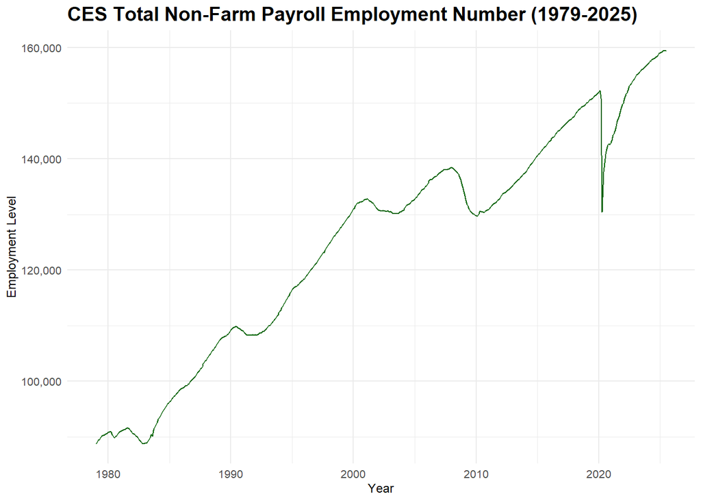

```r
library(ggplot2)

ggplot(ces_joined, aes(x = date, y = level)) +
  geom_line(color = "darkgreen") +
  labs(
    title = "CES Total Non-Farm Payroll Employment Number (1979-2025)",
    x = "Year",
    y = "Employment Level"
  ) +
  scale_y_continuous(labels = scales::comma) +
  theme_minimal(base_size = 9) +
  theme(
    plot.title = element_text(size = 14, face = "bold"),
    axis.title = element_text(size = 9),
    axis.text = element_text(size = 8)
  )
```

#### Largest Revisions in CES History

```r
# Largest positive revision
largest_positive <- ces_joined |>
  slice_max(revision, n = 1)

datatable(
  largest_positive,
  rownames = FALSE,
  caption = tags$caption(
    style = 'caption-side: top; text-align: center; font-size: 20px; font-weight: bold;',"Largest positive revision in CES history"),
  options = list(
    searching = FALSE,
    info = FALSE,
    lengthChange = FALSE,
    paging = FALSE
    )
  )
```

| date | level | original | final | revision | abs_revision | pct_revision |
| --- | --- | --- | --- | --- | --- | --- |
| 2021-11-01 | 149206 | 210 | 647 | 437 | 437 | 68% |

```r
# Largest negative revision
largest_negative <- ces_joined |>
  slice_min(revision, n = 1)

datatable(
  largest_negative,
  rownames = FALSE,
  caption = tags$caption(
    style = 'caption-side: top; text-align: center; font-size: 20px; font-weight: bold;',"Largest negative revision in CES history"),
  options = list(
    searching = FALSE,
    info = FALSE,
    lengthChange = FALSE,
    paging = FALSE
    )
  )
```

| date | level | original | final | revision | abs_revision | pct_revision |
| --- | --- | --- | --- | --- | --- | --- |
| 2020-03-01 | 150895 | -701 | -1373 | -672 | 672 | 49% |

#### Visualization 2: Monthly Non-Farm Payroll Revisions (1979 - 2025)

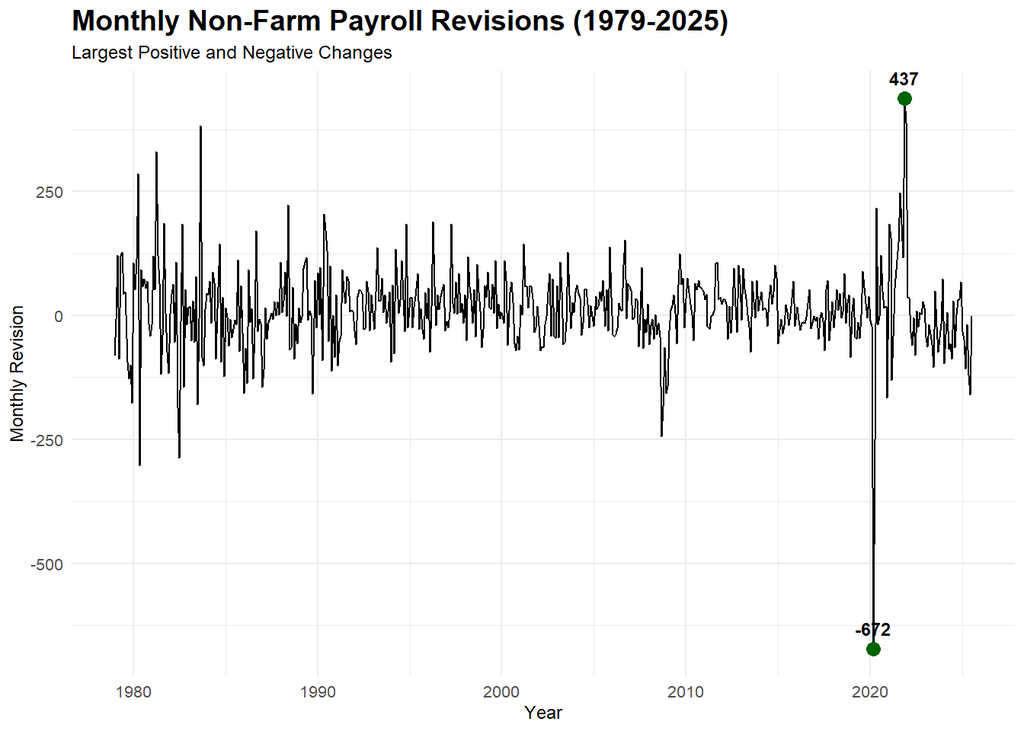

```r
library(dplyr)

# Extract min & max revision rows
extrema <- ces_joined |>
  slice(which.min(revision), which.max(revision))

ggplot(ces_joined, aes(x = date, y = revision)) +
  geom_line() +

  # Highlight min & max
  geom_point(
    data = extrema,
    aes(x = date, y = revision),
    color = c("darkgreen"),
    size = 3
  ) +
  geom_text(
    data = extrema,
    aes(
      label = ifelse(
        revision == max(ces_joined$revision),
        "437",
        "-672"
      )
    ),
    vjust = -1,
    fontface = "bold",
    size = 3
  ) +

  labs(
    title = "Monthly Non-Farm Payroll Revisions (1979-2025)",
    subtitle = "Largest Positive and Negative Changes",
    x = "Year",
    y = "Monthly Revision"
  ) +
  scale_y_continuous(labels = scales::comma) +
  theme_minimal(base_size = 9) +
  theme(
    plot.title = element_text(size = 14, face = "bold"),
    axis.title = element_text(size = 9),
    axis.text = element_text(size = 8)
  )
```

#### Absolute Revision as a Percentage of Overall Employment Level

```r
# Calculate absolute CES revision as a percentage of overall employment level
rev_pct_year <- ces_joined |>
  mutate(
    pct_rev_level = abs_revision / level
  ) |>
  group_by(year = lubridate::year(date)) |>
  summarize(
    avg_rev_pct = mean(pct_rev_level, na.rm = TRUE)
  )

overall_avg_rev_pct <- ces_joined |>
  mutate(
    pct_rev_level = abs_revision / level
  ) |>
  summarize(
    mean_rev_pct = mean(pct_rev_level, na.rm = TRUE)
  )

percent(overall_avg_rev_pct$mean_rev_pct, accuracy = 0.001)
```

```
[1] "0.048%"
```

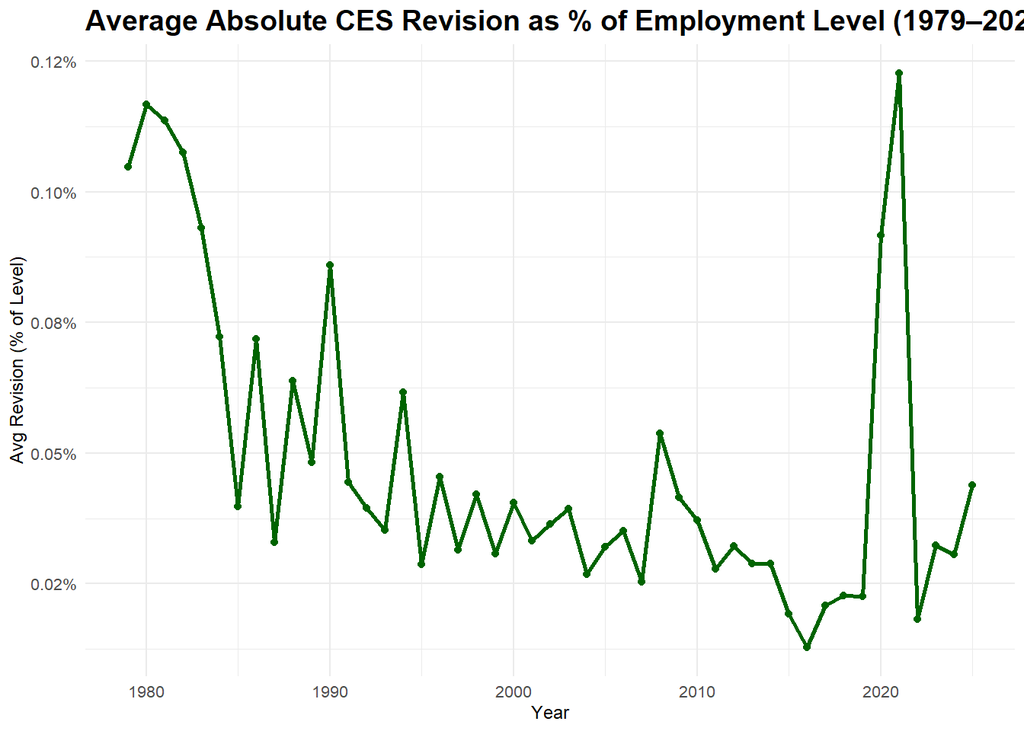

```r
ggplot(rev_pct_year, aes(x = year, y = avg_rev_pct)) +
  geom_line(color = "darkgreen", linewidth = 1) +
  geom_point(color = "darkgreen") +
  scale_y_continuous(labels = scales::percent_format(accuracy = 0.01)) +
  labs(
    title = "Average Absolute CES Revision as % of Employment Level (1979–2025)",
    x = "Year",
    y = "Avg Revision (% of Level)"
  ) +
  theme_minimal(base_size = 9) +
  theme(
    plot.title = element_text(size = 14, face = "bold"),
    axis.title = element_text(size = 9),
    axis.text = element_text(size = 8)
  )
```

#### CES Revisions Statistics by Year and Decade

```r
# Add year and decade column
ces_year <- ces_joined |>
  mutate(
    year = year(date),
    decade = floor(year / 10) * 10
  )

# Fraction of positive revision in each year
positive_year <- ces_year |>
  group_by(year) |>
  summarize(
    fraction_positive = mean(revision > 0, na.rm = TRUE),
    abs_rev = mean(abs_revision)
  ) |>
  arrange(year)

#Display datatable
datatable(
  positive_year,
  rownames = FALSE,
  caption = tags$caption(
    style = 'caption-side: top; text-align: center; font-size: 20px; font-weight: bold;',"CES Revisions Statistics by Year"),
  options = list(
    searching = FALSE,
    info = FALSE,
    lengthChange = FALSE
  )
) |>
  formatPercentage("fraction_positive") |>
  formatRound("abs_rev",1)
```

| year | fraction_positive | abs_rev |
| --- | --- | --- |
| 1979 | 0.4166666666666667 | 94.33333333333333 |
| 1980 | 0.75 | 105.6666666666667 |
| 1981 | 0.5833333333333334 | 103.75 |
| 1982 | 0.5 | 96.33333333333333 |
| 1983 | 0.5 | 84.5 |
| 1984 | 0.6666666666666666 | 68.5 |
| 1985 | 0.25 | 38.83333333333334 |
| 1986 | 0.25 | 71.25 |
| 1987 | 0.4166666666666667 | 33.41666666666666 |
| 1988 | 0.5 | 67.16666666666667 |

[output cut: 37 more lines]

```r
# Fraction of positive revision in each decade
positive_decade <- ces_year |>
  group_by(decade) |>
  summarize(
    fraction_positive = mean(revision > 0, na.rm = TRUE),
    abs_rev = mean(abs_revision)
  ) |>
  arrange(decade)

# Display datatable
datatable(
  positive_decade,
  rownames = FALSE,
  caption = tags$caption(
    style = 'caption-side: top; text-align: center; font-size: 20px; font-weight: bold;',
    "CES Revisions Statistics by Decade"
  ),
  options = list(
    searching = FALSE,
    info = FALSE,
    lengthChange = FALSE,
    paging = FALSE
    )
  ) |>
  formatPercentage("fraction_positive") |>
  formatRound("abs_rev",1)
```

| decade | fraction_positive | abs_rev |
| --- | --- | --- |
| 1970 | 0.4166666666666667 | 94.33333333333333 |
| 1980 | 0.4916666666666666 | 72.15 |
| 1990 | 0.6916666666666667 | 51.41666666666666 |
| 2000 | 0.5416666666666666 | 48.55833333333333 |
| 2010 | 0.625 | 35.19166666666667 |
| 2020 | 0.4626865671641791 | 85.65671641791045 |

#### Visualization 3: Fraction of Positive CES Revisions by Month (1979-2025)

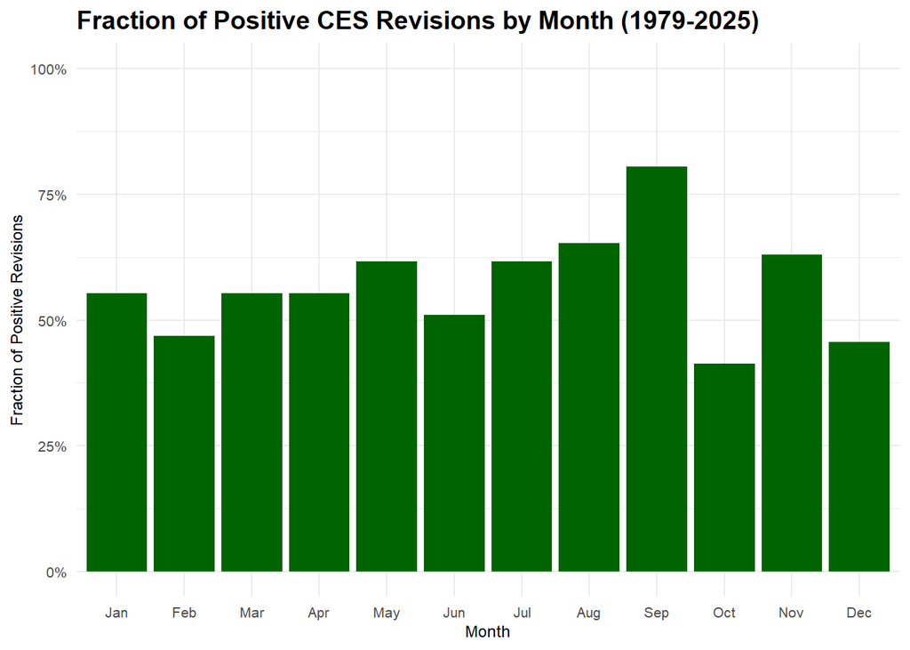

```r
# Aggregate fraction of positive revision by Month
ces_month <- ces_joined |>
  mutate(
    month = month(date, label = TRUE, abbr = TRUE)

  )
positive_month <- ces_month |>
  group_by(month) |>
  summarize(
    fraction_positive = mean(revision > 0, na.rm = TRUE),
    abs_rev = mean(abs_revision)
  ) |>
  arrange(month)

# Plot share of positive revision in each month
ggplot(positive_month, aes(month, fraction_positive)) +
  geom_col(fill = "darkgreen") +
  scale_y_continuous(labels = scales::percent, limits = c(0, 1)) +
  labs(
    title = "Fraction of Positive CES Revisions by Month (1979-2025)",
    x = "Month",
    y = "Fraction of Positive Revisions"
  ) +
  theme_minimal()+
  theme(
    plot.title = element_text(size = 14, face = "bold"),
    axis.title = element_text(size = 9),
    axis.text = element_text(size = 8)
  )
```